# Practical Machine Learning Course Project

Nazri Othman

December 26, 2015

```r
# set the echo to TRUE and warning to FALSE as global options for this document
library(knitr)
opts_chunk$set(echo=TRUE, warning=FALSE)

# load the appropriate packages
library(caret)
library(rpart)
library(rpart.plot)
library(RColorBrewer)
library(rattle)
library(randomForest)
```

# Synopsis

### Background

Now, it is possible to collect a large amount of data about personal activity relatively inexpensively by using devices such as Jawbone Up, Nike FuelBand, and Fitbit. One thing that people regularly do is quantify how much of a particular activity they do, but they rarely quantify how well they do it.

In this project, we will use data from accelerometers on the belt, forearm, arm, and dumbell of 6 participants. They were asked to perform barbell lifts correctly and incorrectly in 5 different ways.

More information is available from the website here: http://groupware.les.inf.puc-rio.br/har (see the section on the Weight Lifting Exercise Dataset).

### Data Input

The training data for this project are available here: https://d396qusza40orc.cloudfront.net/predmachlearn/pml-training.csv

The test data are available here: https://d396qusza40orc.cloudfront.net/predmachlearn/pml-testing.csv

The data for this project come from this source: http://groupware.les.inf.puc-rio.br/har.

### Objectives

This project is to predict the manner in which the 6 participants did their exercise. This is the “classe” variable in the training set.

We may use any of the other variables to predict with. We should then create a report describing,

We will also use our prediction model to predict 20 different test cases.

# Loading the data

```r
set.seed(4472)

trainURL <- "http://d396qusza40orc.cloudfront.net/predmachlearn/pml-training.csv"
testURL <- "http://d396qusza40orc.cloudfront.net/predmachlearn/pml-testing.csv"

trainingData <- read.csv(url(trainURL), na.strings=c("NA","#DIV/0!",""))
testingData <- read.csv(url(testURL), na.strings=c("NA","#DIV/0!",""))
```

Partition the training data into two

```r
inTrain <- createDataPartition(trainingData$classe, p=0.6, list=FALSE)

myTrainingData <- trainingData[inTrain, ]
myTestingData <- trainingData[-inTrain, ]

dim(myTrainingData); dim(myTestingData)
```

```
## [1] 11776   160
```

```
## [1] 7846  160
```

# Cleaning the data

```r
# Remove Near Zero Variance variables
nzv <- nearZeroVar(myTrainingData, saveMetrics=TRUE)
myTrainingData <- myTrainingData[,nzv$nzv==FALSE]
nzv <- nearZeroVar(myTestingData,saveMetrics=TRUE)
myTestingData <- myTestingData[,nzv$nzv==FALSE]

# Remove the first column of the myTraining data set
myTrainingData <- myTrainingData[c(-1)]


# Clean variables with more than 60% NA
temp <- myTrainingData
for(i in 1:length(myTrainingData)) {
    if( sum( is.na( myTrainingData[, i] ) ) /nrow(myTrainingData) >= .7) {
        for(j in 1:length(temp)) {
            if( length( grep(names(myTrainingData[i]), names(temp)[j]) ) == 1)  {
                temp <- temp[ , -j]
            }
        }
    }
}

myTrainingData <- temp
rm(temp)

# remove the classe column
cleanData1 <- colnames(myTrainingData)
cleanData2 <- colnames(myTrainingData[, -58])

# allow only variables in myTestingData that are also in myTrainingData
myTestingData <- myTestingData[cleanData1]

# allow only variables in testing that are also in myTrainingData
testingData <- testingData[cleanData2]

dim(myTestingData)
```

```
## [1] 7846   58
```

```r
dim(testingData)
```

```
## [1] 20 57
```

```r
# Coerce the data into the same type
for (i in 1:length(testingData) ) {
    for(j in 1:length(myTrainingData)) {
        if( length( grep(names(myTrainingData[i]), names(testingData)[j]) ) == 1)  {
            class(testingData[j]) <- class(myTrainingData[i])
        }
    }
}

# Get the same class between testingData and myTrainingData
testingData <- rbind(myTrainingData[2, -58] , testingData)
testingData <- testingData[-1,]
```

# Prediction with Decision Trees

[figure not shown]

```r
set.seed(4472)
modFitA1 <- rpart(classe ~ ., data=myTrainingData, method="class")
fancyRpartPlot(modFitA1)
```

```r
predictionsA1 <- predict(modFitA1, myTestingData, type = "class")
cmtree <- confusionMatrix(predictionsA1, myTestingData$classe)
cmtree
```

```
## Confusion Matrix and Statistics
##
##           Reference
## Prediction    A    B    C    D    E
##          A 2153   60    6    3    0
##          B   57 1252   86   66    0
##          C   22  193 1257  197   53
##          D    0   13   10  827   92
##          E    0    0    9  193 1297
##
## Overall Statistics
##
##                Accuracy : 0.8649
##                  95% CI : (0.8571, 0.8724)
##     No Information Rate : 0.2845
##     P-Value [Acc > NIR] : < 2.2e-16
##
##                   Kappa : 0.8291
##  Mcnemar's Test P-Value : NA
##
## Statistics by Class:
##
##                      Class: A Class: B Class: C Class: D Class: E
## Sensitivity            0.9646   0.8248   0.9189   0.6431   0.8994
## Specificity            0.9877   0.9670   0.9282   0.9825   0.9685
## Pos Pred Value         0.9689   0.8569   0.7300   0.8779   0.8652
## Neg Pred Value         0.9860   0.9583   0.9819   0.9335   0.9772
## Prevalence             0.2845   0.1935   0.1744   0.1639   0.1838
## Detection Rate         0.2744   0.1596   0.1602   0.1054   0.1653
## Detection Prevalence   0.2832   0.1862   0.2195   0.1201   0.1911
## Balanced Accuracy      0.9762   0.8959   0.9235   0.8128   0.9340
```

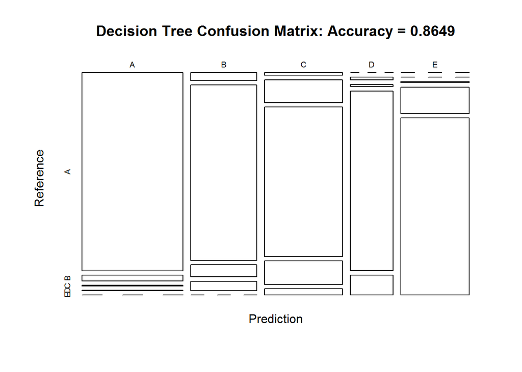

```r
plot(cmtree$table, col = cmtree$byClass, main = paste("Decision Tree Confusion Matrix: Accuracy =", round(cmtree$overall['Accuracy'], 4)))
```

# Prediction with Random Forests

```r
set.seed(4472)
modFitB1 <- randomForest(classe ~ ., data=myTrainingData)
predictionB1 <- predict(modFitB1, myTestingData, type = "class")
cmrf <- confusionMatrix(predictionB1, myTestingData$classe)
cmrf
```

```
## Confusion Matrix and Statistics
##
##           Reference
## Prediction    A    B    C    D    E
##          A 2231    5    0    0    0
##          B    1 1513    1    0    0
##          C    0    0 1363    1    0
##          D    0    0    4 1285    0
##          E    0    0    0    0 1442
##
## Overall Statistics
##
##                Accuracy : 0.9985
##                  95% CI : (0.9973, 0.9992)
##     No Information Rate : 0.2845
##     P-Value [Acc > NIR] : < 2.2e-16
##
##                   Kappa : 0.9981
##  Mcnemar's Test P-Value : NA
##
## Statistics by Class:
##
##                      Class: A Class: B Class: C Class: D Class: E
## Sensitivity            0.9996   0.9967   0.9963   0.9992   1.0000
## Specificity            0.9991   0.9997   0.9998   0.9994   1.0000
## Pos Pred Value         0.9978   0.9987   0.9993   0.9969   1.0000
## Neg Pred Value         0.9998   0.9992   0.9992   0.9998   1.0000
## Prevalence             0.2845   0.1935   0.1744   0.1639   0.1838
## Detection Rate         0.2843   0.1928   0.1737   0.1638   0.1838
## Detection Prevalence   0.2850   0.1931   0.1738   0.1643   0.1838
## Balanced Accuracy      0.9993   0.9982   0.9981   0.9993   1.0000
```

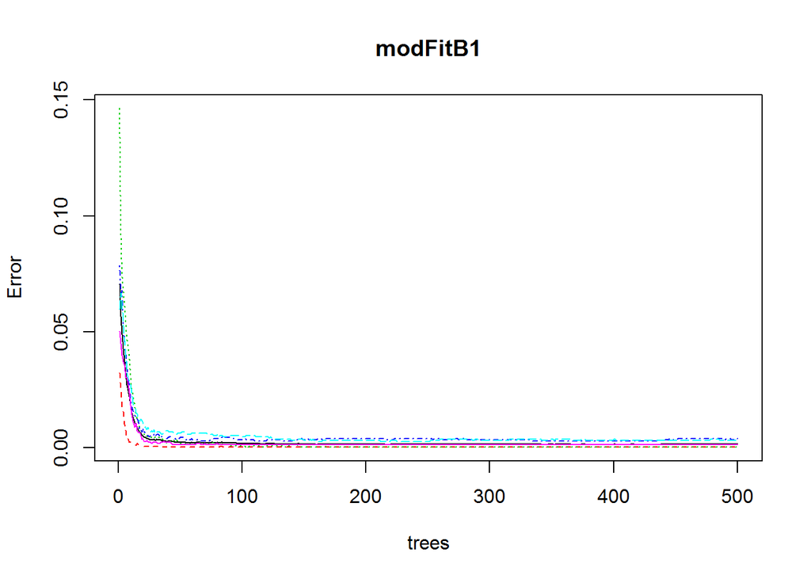

```r
plot(modFitB1)
```

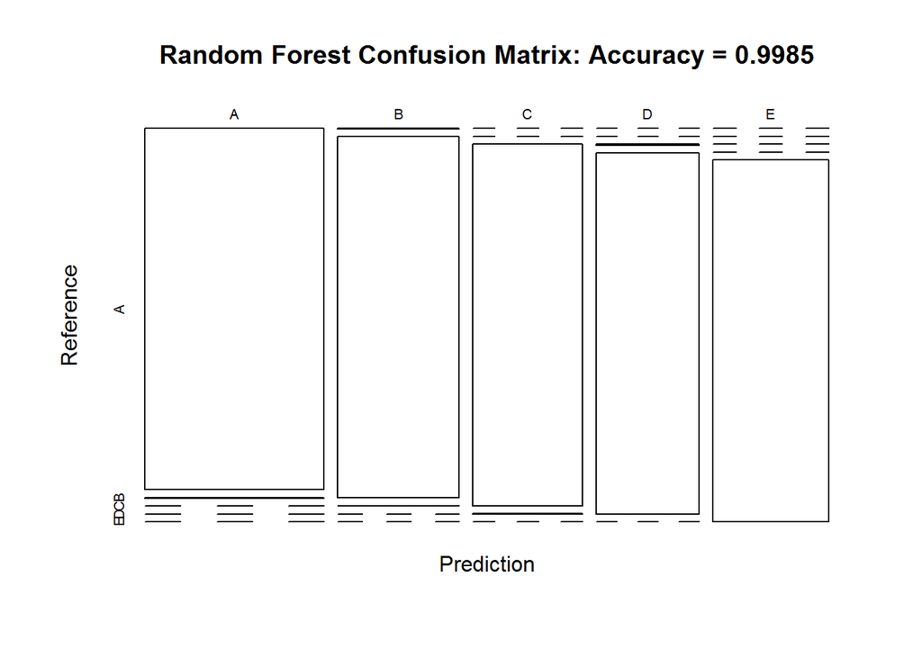

```r
plot(cmrf$table, col = cmtree$byClass, main = paste("Random Forest Confusion Matrix: Accuracy =", round(cmrf$overall['Accuracy'], 4)))
```

# Predicting Results on the Test Data

```r
predictionB2 <- predict(modFitB1, testingData, type = "class")
predictionB2
```

```
##  2 31  4  5  6  7  8  9 10 11 12 13 14 15 16 17 18 19 20 21
##  B  A  B  A  A  E  D  B  A  A  B  C  B  A  E  E  A  B  B  B
## Levels: A B C D E
```

```r
# Write the results to a text file for submission
pml_write_files = function(x){
    n = length(x)
    for(i in 1:n){
        filename = paste0("problem_id_",i,".txt")
        write.table(x[i],file=filename,quote=FALSE,row.names=FALSE,col.names=FALSE)
    }
}

pml_write_files(predictionB2)
```